# Homework 1

Abishev Daur

## Задание 1

Будем использовать дата фрейм Bwt.csv. Исследования здоровья и развития детей, проведенных в Окленде, Калифорния, больнице Фонда Кайзера.

```r
df  <- read.csv("Bwt.csv")
df <- df[-c(1)]
df$smoke<-factor(df$smoke,c(0,1),labels=c('Non-smoker','Smoker'))
df$parity<-factor(df$parity,c(0,1),labels=c('Other','Firstborn'))
```

Дата фрейм состоит из 1174 наблюдений и 7 переменных. Переменные:

**bwt**: вес ребенка в унциях при рождении

**parity**: показатель паритета (первенец = 1, иначе = 0)

**age**: возраст матери в годах

**height**: рост матери в дюймах

**weight**: вес матери в фунтах (во время беременности)

**smoke** : индикатор того, курит ли мать (1 = да, 0 = нет)

## Задание 2

В дата фрейме нет пустых значений:

```r
sum(is.na(df))
```

```
## [1] 0
```

Посмотрим краткое описание дата фрейма:

```r
str(df)
```

```
## 'data.frame':    1174 obs. of  7 variables:
##  $ bwt      : int  120 113 128 108 136 138 132 120 143 140 ...
##  $ gestation: int  284 282 279 282 286 244 245 289 299 351 ...
##  $ parity   : Factor w/ 2 levels "Other","Firstborn": 1 1 1 1 1 1 1 1 1 1 ...
##  $ age      : int  27 33 28 23 25 33 23 25 30 27 ...
##  $ height   : int  62 64 64 67 62 62 65 62 66 68 ...
##  $ weight   : int  100 135 115 125 93 178 140 125 136 120 ...
##  $ smoke    : Factor w/ 2 levels "Non-smoker","Smoker": 1 1 2 2 1 1 1 1 2 1 ...
```

```r
summary(df)
```

```
##       bwt          gestation           parity         age
##  Min.   : 55.0   Min.   :148.0   Other    :866   Min.   :15.00
##  1st Qu.:108.0   1st Qu.:272.0   Firstborn:308   1st Qu.:23.00
##  Median :120.0   Median :280.0                   Median :26.00
##  Mean   :119.5   Mean   :279.1                   Mean   :27.23
##  3rd Qu.:131.0   3rd Qu.:288.0                   3rd Qu.:31.00
##  Max.   :176.0   Max.   :353.0                   Max.   :45.00
##      height          weight             smoke
##  Min.   :53.00   Min.   : 87.0   Non-smoker:715
##  1st Qu.:62.00   1st Qu.:114.2   Smoker    :459
##  Median :64.00   Median :125.0
##  Mean   :64.05   Mean   :128.5
##  3rd Qu.:66.00   3rd Qu.:139.0
##  Max.   :72.00   Max.   :250.0
```

```r
names(df)
```

```
## [1] "bwt"       "gestation" "parity"    "age"       "height"    "weight"
## [7] "smoke"
```

**Рассмотрим несколько графиков:**

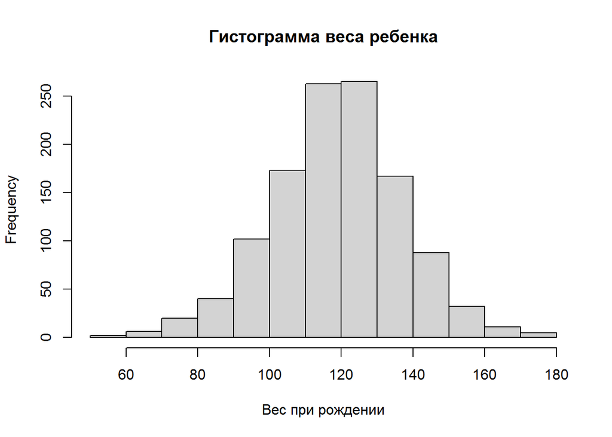

```r
hist(df$bwt, xlab='Вес при рождении', main = 'Гистограмма веса ребенка')
```

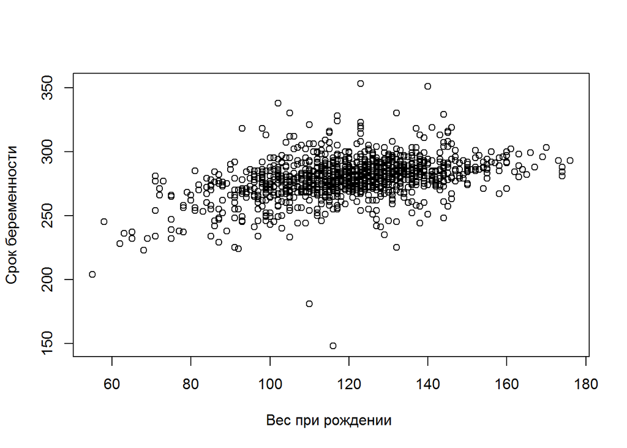

```r
plot(df$bwt, df$gestation,xlab='Вес при рождении ',ylab='Срок беременности')
```

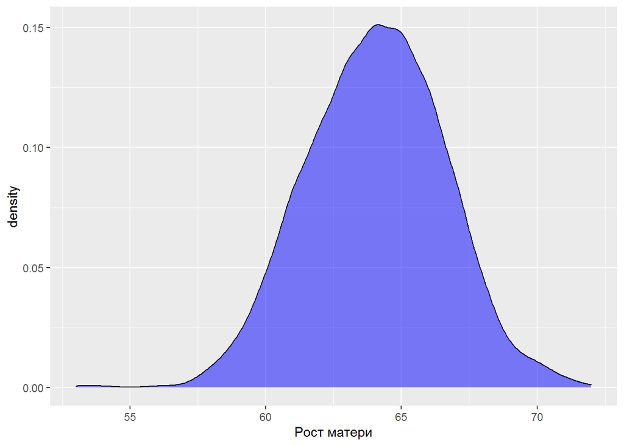

```r
ggplot(df, aes(x= height))+
  geom_density(fill = 'blue', alpha = 0.5) +
  xlab('Рост матери')
```

## Задание 3

Выделим две группы матерей: курящих и не курящих:

```r
smok <- subset(df, smoke == 'Smoker')
nosmok <- subset(df, smoke == 'Non-smoker')
```

Проверим гипотезу о равенстве среднего роста для этих двух групп (курящих, не курящих):

```r
t.test(smok$height, nosmok$height, alternarive = "two.sided")
```

```
##
##  Welch Two Sample t-test
##
## data:  smok$height and nosmok$height
## t = 0.59289, df = 940.79, p-value = 0.5534
## alternative hypothesis: true difference in means is not equal to 0
## 95 percent confidence interval:
##  -0.2092639  0.3904422
## sample estimates:
## mean of x mean of y
##  64.10458  64.01399
```

Статистический вывод: на 5%-ном уровне значимости на наших данных нет оснований отвергнуть нулевую гипотезу в пользу альтернативной (p−value > aplha). Содержательный вывод: средний рост курящих и не курящих матерей равны.

Построим теперь 95% доверительные интервалы для среднего и дисперсии по одной из количественных переменных. Возьмем количественную переменную *age* возраст матери.

```r
t.test(df$age, conf.level = 0.95)
```

```
##
##  One Sample t-test
##
## data:  df$age
## t = 160.36, df = 1173, p-value < 2.2e-16
## alternative hypothesis: true mean is not equal to 0
## 95 percent confidence interval:
##  26.89514 27.56142
## sample estimates:
## mean of x
##  27.22828
```

95% доверительный интервал для среднего (26.895, 27.561).

```r
n <- length(df$age) - 1
varage <- var(df$age)
lower <-  varage * n / qchisq(0.05/2, n, lower.tail = FALSE)
upper <-  varage * n / qchisq(1 - 0.05/2, n, lower.tail = FALSE)
c(lower = lower, variance = varage, upper = upper)
```

```
##    lower variance    upper
## 31.26670 33.84725 36.76268
```

95% доверительный интервал для дисперсии (31.266, 36.762).

## Задание 4

Выберем только количественные переменные из нашего дата фрейма:

```r
df_num <- df[,-c(3,7)]
```

Построим корреляционну матрицу по нашим количественным переменным:

```r
cor(df_num)
```

```
##                  bwt   gestation          age       height     weight
## bwt       1.00000000  0.40754279  0.026982911  0.203704177 0.15592327
## gestation 0.40754279  1.00000000 -0.053424774  0.070469902 0.02365494
## age       0.02698291 -0.05342477  1.000000000 -0.006452846 0.14732211
## height    0.20370418  0.07046990 -0.006452846  1.000000000 0.43528743
## weight    0.15592327  0.02365494  0.147322111  0.435287428 1.00000000
```

Попарные диаграммы рассеяния будут выглядеть следующим образом:

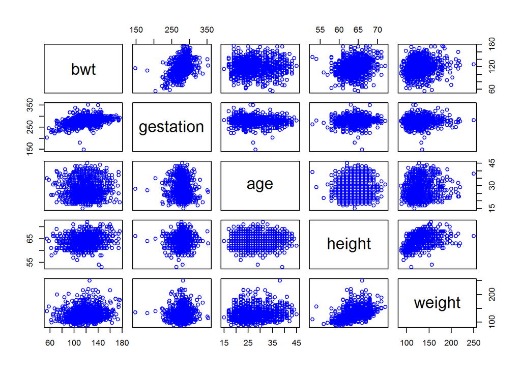

```r
pairs(df_num, col = 'blue')
```

Почти все наши параметры слабо коррелированы так как больше -0.5 и меньше 0.5. Самая большая корреляция 0.4352 между ростом и весом. Самая маленькая между ростом и возрастом -0.00645.

Рассчитаем значение множественного коэффициента корреляции. bwt от остальных переменных:

```r
model<-lm(bwt~gestation+smoke+weight+ parity + age + height, data = df)
cor(model$model$bwt, model$fitted.values)
```

```
## [1] 0.5078912
```

Посчитаем частный коэффициент корреляции между bwt и gestation. Вызываем функцию pcor из библиотеки ggm. Первые два аргумента – номера переменных, для которых нужно вычислить коэффициент, а остальные аргументы – номера «влияющих» переменных (воздействие которых должно быть отделено).

```r
pcor(c('bwt','gestation','age','height','weight'), var(df_num))
```

```
## [1] 0.4058771
```

Возьмем два произвольных номинальных признака age, height. Проверим гипотезу о независимости двух признаков. Воспользуемся функцией chisq.test для более точного теста Фишера, напишем simulate.p.value = TRUE:

```r
chisq.test(table(df$age, df$height),simulate.p.value = TRUE)
```

```
##
##  Pearson's Chi-squared test with simulated p-value (based on 2000
##  replicates)
##
## data:  table(df$age, df$height)
## X-squared = 468, df = NA, p-value = 0.6572
```

Как мы видим p-value > 0.05. На имеющихся данных на уровне значимости 5% нет оснований отвергнуть нулевую гипотезу о том, что признаки независимы.

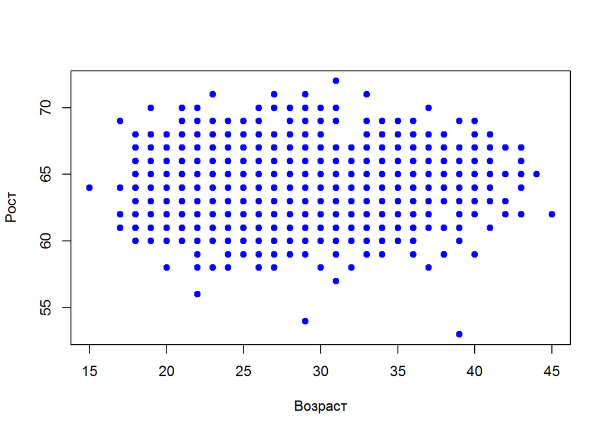

```r
plot(df$age, df$height,xlab = "Возраст",
     ylab = "Рост",
     pch = 19, col = 'blue')
```

## Задание 5

Линейная регрессия.

Зависимая переменная: Вес ребенка при рождении.

На первый взгляд кажется, что все предикторы: срок беременности, показатель паритета, возраст матери, рост матери, вес матери, курит ли мать подходят, и не понятно какой из признаков удалить, и стоит ли вообще это делать. Выясним это:

```r
model<-lm(bwt~gestation+smoke+weight+ parity + age + height, data = df)
```

Найдем оптимальную модель. Для этого воспользуемся функции step с направлением backward:

```r
optimal <- step(model, direction = 'backward')
```

```
## Start:  AIC=6491.82
## bwt ~ gestation + smoke + weight + parity + age + height
##
##             Df Sum of Sq    RSS    AIC
## - age        1         3 292412 6489.8
## <none>                   292409 6491.8
## - weight     1       990 293399 6493.8
## - parity     1      2176 294586 6498.5
## - height     1      7939 300348 6521.3
## - smoke      1     19437 311846 6565.4
## - gestation  1     58334 350744 6703.4
##
## Step:  AIC=6489.83
## bwt ~ gestation + smoke + weight + parity + height
##
##             Df Sum of Sq    RSS    AIC
## <none>                   292412 6489.8
## - weight     1       992 293404 6491.8
## - parity     1      2396 294808 6497.4
## - height     1      7968 300380 6519.4
## - smoke      1     19497 311909 6563.6
## - gestation  1     58421 350833 6701.7
```

```r
summary(optimal)
```

```
##
## Call:
## lm(formula = bwt ~ gestation + smoke + weight + parity + height,
##     data = df)
##
## Residuals:
##     Min      1Q  Median      3Q     Max
## -57.716 -10.150  -0.159   9.689  51.620
##
## Coefficients:
##                  Estimate Std. Error t value Pr(>|t|)
## (Intercept)     -80.71321   14.04465  -5.747 1.16e-08 ***
## gestation         0.44408    0.02907  15.276  < 2e-16 ***
## smokeSmoker      -8.39390    0.95117  -8.825  < 2e-16 ***
## weight            0.04983    0.02503   1.991  0.04672 *
## parityFirstborn  -3.28762    1.06281  -3.093  0.00203 **
## height            1.15497    0.20473   5.641 2.11e-08 ***
## ---
## Signif. codes:  0 '***' 0.001 '**' 0.01 '*' 0.05 '.' 0.1 ' ' 1
##
## Residual standard error: 15.82 on 1168 degrees of freedom
## Multiple R-squared:  0.2579, Adjusted R-squared:  0.2548
## F-statistic:  81.2 on 5 and 1168 DF,  p-value: < 2.2e-16
```

Как видно признак age отсутствует. Следовательно, можно убрать этот признак. Улучшим нашу модель выкинув предиктор age:

```r
model_optimal<-lm(bwt~gestation+smoke+weight+ parity  + height, data = df)
summod <- summary(model_optimal)
summod
```

```
##
## Call:
## lm(formula = bwt ~ gestation + smoke + weight + parity + height,
##     data = df)
##
## Residuals:
##     Min      1Q  Median      3Q     Max
## -57.716 -10.150  -0.159   9.689  51.620
##
## Coefficients:
##                  Estimate Std. Error t value Pr(>|t|)
## (Intercept)     -80.71321   14.04465  -5.747 1.16e-08 ***
## gestation         0.44408    0.02907  15.276  < 2e-16 ***
## smokeSmoker      -8.39390    0.95117  -8.825  < 2e-16 ***
## weight            0.04983    0.02503   1.991  0.04672 *
## parityFirstborn  -3.28762    1.06281  -3.093  0.00203 **
## height            1.15497    0.20473   5.641 2.11e-08 ***
## ---
## Signif. codes:  0 '***' 0.001 '**' 0.01 '*' 0.05 '.' 0.1 ' ' 1
##
## Residual standard error: 15.82 on 1168 degrees of freedom
## Multiple R-squared:  0.2579, Adjusted R-squared:  0.2548
## F-statistic:  81.2 on 5 and 1168 DF,  p-value: < 2.2e-16
```

Метрика MSE - измеряет среднюю сумму квадратной разности между фактическим значением и прогнозируемым значением для всех точек данных. Найдем MSE для наших данных:

```r
MSE <- mean(summod$residuals^2)
```

R^2 - коэффициент детерминации на сколько наша модель лучше, чем константное решение или как достоверность соответствия набора прогнозов фактическим значениям.

```r
R2 <- summod$r.squared
```

R2adj - скорректированный R2. Для того, чтобы была возможность сравнивать модели с разным числом признаков.

```r
R2adj <-summod$adj.r.squared
```

В самой первой модели R2adj равнялся 0.2541, и после того, как мы убрали признак age R2adj, стал равным 0.2548, то есть увеличился. Следовательно, мы не зря его убрали.

St.err остаточная стандартная ошибка. В нашей модели она равняется 15.82.

F_statistics используется для оценки значимости модели регрессии в целом, является соотношением объяснимой дисперсии, к необъяснимой. Если модель линейной регрессии построена удачно, то она объясняет значительную часть дисперсии, оставляя в знаменателе малую часть. Чем больше значение параметра — тем лучше.

```r
F_statistics <- summod$fstatistic
```

p_value . В столбце р-значение приводится достоверность отличия соответствующих коэффициентов от нуля. В случае, когда р>0.05, коэффициент может считаться нулевым. Это означает, что соответствующая независимая переменная практически не влияет на зависимую переменную, и коэффициент может быть убран из уравнения. В нашей модели все p_value меньше 0.05. Но признак weight близок к 0.05, и как показала t статистика, этот фактор не сильно значим для нашей модели.

Построим доверительный интервалы для всех параметров:

```r
confint(model_optimal)
```

```
##                         2.5 %       97.5 %
## (Intercept)     -1.082688e+02 -53.15765131
## gestation        3.870403e-01   0.50111208
## smokeSmoker     -1.026009e+01  -6.52771691
## weight           7.247590e-04   0.09894223
## parityFirstborn -5.372856e+00  -1.20239124
## height           7.532930e-01   1.55664866
```

Чем шире доверительный интервал для заданного уровня вероятности (скажем, 95%), тем ниже уровень «доверия» к выборочным оценкам, и наоборот.